# OOPS_4

### Using Members of One Class inside Another Class:

1. By Composition (Has-A Relationship)
2. By Inheritance(IS-A Relationship)

#### 1) By Composition (Has-A Relationship):

```
-By using Class Name or by creating object we can access members of one class inside another class is nothing but composition (Has-A Relationship).
-The main advantage of Has-A Relationship is Code Reusability.
```

```python
class Engine():
    a = 10
    def __init__(self):
        self.b = 20
    def m1(self):
        print("Engine Specific Functionalilty")
class Car():
    def __init__(self):
        self.engine = Engine()
    def m2(self):
        print('Car using Engine Class Functionality')
        print(self.engine.a)
        print(self.engine.b)
        self.engine.m1()
c=Car()
c.m2()
```

```
Car using Engine Class Functionality
10
20
Engine Specific Functionalilty
```

```python
class Car():
    def __init__(self,name,model,color):
        self.name=name
        self.model=model
        self.color=color
    def getinfo(self):
        print("Car Name:{} , Model:{} and Color:{}".format(self.name,self.model,self.color))
class Employee():
    def __init__(self,ename,eno,car):
        self.ename=ename
        self.eno=eno
        self.car=car
    def empinfo(self):
        print("Employee Name:",self.ename)
        print("Employee Number:",self.eno)
        print("Employee Car Info:")
        self.car.getinfo()
c=Car("Innova","2.5V","Grey")
e=Employee('Durga',10000,c)
e.empinfo()
```

```
Employee Name: Durga
Employee Number: 10000
Employee Car Info:
Car Name:Innova , Model:2.5V and Color:Grey
```

#### 2) By Inheritance (IS-A Relationship):

What ever variables, methods and constructors available in the parent class by default available to the child classes and we are not required to rewrite. Hence the main advantage of inheritance is Code Reusability and we can extend existing functionality with some more extra functionality.

```python
class P:
    a=10
    def __init__(self):
        self.b=10
    def m1(self):
        print('Parent instance method')
    @classmethod
    def m2(cls):
        print('Parent class method')
    @staticmethod
    def m3():
        print('Parent static method')

class C(P):
    pass

c=C()
print(c.a)
print(c.b)
c.m1()
c.m2()
c.m3()
```

```
10
10
Parent instance method
Parent class method
Parent static method
```

```python
class Person:
    def __init__(self,name,age):
        self.name=name
        self.age=age
    def  eatndrink(self):
        print('Eat Biryani and Drink Beer')

class Employee(Person):
    def __init__(self,name,age,eno,esal):
        super().__init__(name,age)
        self.eno=eno
        self.esal=esal

    def work(self):
        print("Coding Python is very easy just like drinking Chilled Beer")
    def empinfo(self):
        print("Employee Name:",self.name)
        print("Employee Age:",self.age)
        print("Employee Number:",self.eno)
        print("Employee Salary:",self.esal)

e=Employee('Durga', 48, 100, 10000)
e.eatndrink()
e.work()
e.empinfo()
```

```
Eat Biryani and Drink Beer
Coding Python is very easy just like drinking Chilled Beer
Employee Name: Durga
Employee Age: 48
Employee Number: 100
Employee Salary: 10000
```

#### INHERITANCE:

Reuse-Class Members-Attributes & Methods  
OR  
It is the process of inheriting the class members from one class to another class is called Inheritance.  
OR  
The concept of using properties of one class into another class without creating object of that class explicitly is known as inheritance.  
OR  
1 A class which is extended by another class is known as 'super class'.  
2 Both super class property and sub class property can be accessed through sublcass ref.variable

Types of Inheritance(s):

1. Single Level Inheritance
2. Multilevel Inheritance
3. Multiple Inheritance
4. Hierarchial Inheritance
5. Hybrid Inheritance
6. Diamond/Cyclic Inheritance

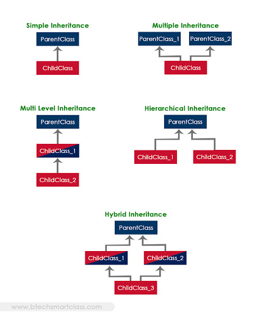

```python
class Animal():
    def Eat(self):
        print("All Animals are Eating...!!")
class Dog():
    def Eat(self):
        print("Dog is Eating")
    def Sound(self):
        print("Dog is Barking")
class Cat():
    def Eat(self):
        print("Cat is also Eating")
    def Sound(self):
        print("Cat is mewwwwwwwwwwwwwww..!")
class Lion():
    def Eat(self):
        print("Lion is Eating...!!")
    def Sound(self):
        print("Lion is Roraring........")

AA=Animal()
AA.Eat()
DD=Dog()
DD.Eat()
DD.Sound()
CC=Cat()
CC.Eat()
CC.Sound()
LL=Lion()
LL.Eat()
LL.Sound()
```

```
All Animals are Eating...!!
Dog is Eating
Dog is Barking
Cat is also Eating
Cat is mewwwwwwwwwwwwwww..!
Lion is Eating...!!
Lion is Roraring........
```

```python
class Animal():
    def Eat(self):
        print("All Animals are Eating...!")
class Dog(Animal):
    def Sound(self):
        print("Dog is Barking....!")
class Cat(Animal):
    def Sound(self):
        print("Cat is mewwwwwww....!")
class Lion(Animal):
    def Sound(self):
        print("Lion is Roraring....!")

dd = Dog()
dd.Eat()
dd.Sound()
cc = Cat()
cc.Eat()
cc.Sound()
ll = Lion()
ll.Eat()
ll.Sound()
```

[output not shown]

#### Terminology:

Parent class ==> Base class ==>Super class  
Child class ==> Derived class==> Sub class

#### Single Level Inheritance

The concept of inheriting properties from only one class into another class is known as single level inheritance.

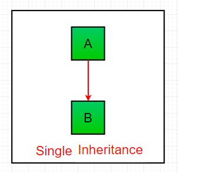

```python
class Animal():
    def Eating(self):
        print("Animals are Eating ...!!")
class Dog(Animal):
    def Sound(self):
        print("Dog is Barking....!!!")

dd = Dog()
dd.Eating()
dd.Sound()
```

```
Animals are Eating ...!!
Dog is Barking....!!!
```

```python
class Animal():
    def __init__(self,name):
        self.name = name
class Dog(Animal):
    def Display(self):
        print("Hello:", self.name)

dd = Dog("Beagle")
dd.Display()
```

```
Hello: Beagle
```

```python
class Banker():
    def Services(self):
        print("Every Bank Provide Services to Customers")
class Customer(Banker):
    def Cust_Ser(self):
        print("Customer using all services from Banker")
CC=Customer()
CC.Services()
CC.Cust_Ser()
```

```
Every Bank Provide Services to Customers
Customer using all services from Banker
```

#### Multilevel Inheritance

You can inherit a derived class from another derived class.

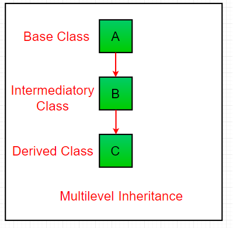

```python
class Animal():
    def Eat(self):
        print("All Animals are Eating...!")
class Dog(Animal):
    def Sound(self):
        print("Dog is Barking....!")
class BabyDog(Dog):
    def Sound(self):
        print("Baby Dog is weeping....!")


dd = BabyDog()
dd.Eat()
dd.Sound()
```

```
All Animals are Eating...!
Baby Dog is weeping....!
```

```python
class Finacial_Services_India():
    def FSI(self):
        print("All Permissions from here")
        print("It is related Finance")
class ReserveBankofIndia(Finacial_Services_India):
    def RBI(self):
        print("It is leading All Bankers in INDIA")
        print("Thank u RBI")
class Bankers_India(ReserveBankofIndia):
    def Bank_INDIA(self):
        print("Welcome to Indian Banks")
        print("We are ready to serve")
        print("We deal Finanacial Matters")
BI=Bankers_India()
BI.FSI()
BI.RBI()
BI.Bank_INDIA()
```

```
All Permissions from here
It is related Finance
It is leading All Bankers in INDIA
Thank u RBI
Welcome to Indian Banks
We are ready to serve
We deal Finanacial Matters
```

```python
class grandfather():
    def wish_gf(self):
        print('Hey grandfather!!!')
class father(grandfather):
    def wish_f(self):
        print('Hey father!!!')
class son(father):
    def wish_s(self):
        print('Hey son!!!')

ss = son()
ss.wish_gf()
ss.wish_f()
ss.wish_s()
```

```
Hey grandfather!!!
Hey father!!!
Hey son!!!
```

#### Multiple Inheritance

You can derive a child class from more than one base (parent) class.

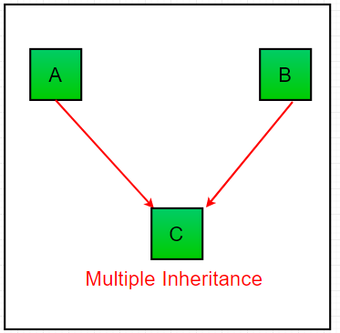

```python
class A():
    def MyMethod(self):
        print("I am in Class A")
class B():
    def MyMethod(self):
        print("I am in Class B")
class C(A,B):
    pass

test = C()
test.MyMethod()
```

```
I am in Class A
```

```python
class A():
    pass
class B():
    def MyMethod(self):
        print("I am in Class B")
class C(A,B):
    pass

test = C()
test.MyMethod()
```

```
I am in Class B
```

```python
class A():
    def MyMethod(self):
        print("I am in Class A")
class B():
    def MyMethod(self):
        print("I am in Class B")
class C(B,A):
    pass

test = C()
test.MyMethod()
```

```
I am in Class B
```

```python
class p1():
    def m1(self):
        print("parent1 Method")
class p2():
    def m1(self):
        print("parent2 Method")
class c(p1,p2):
    def m2(self):
        print("child Method")

jj = c()
jj.m1()
jj.m2()
```

```
parent1 Method
child Method
```

#### Hierarchical Inheritance:-

The concept of inheriting properties from one class into multiple classes is known as a hierarchical inheritance

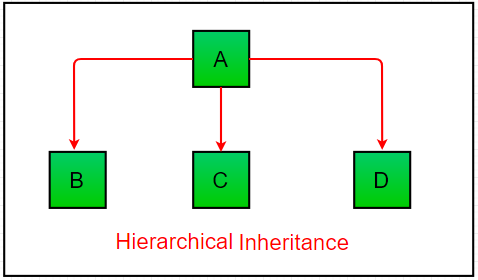

```python
class Banker():
    def Bank_Services(self):
        print("Welcome to Banking Services")
class EBanking(Banker):
    def Email(self):
        print("Welcome to Email Banking")
class Banking_Mobile(Banker):
    def Mobile(self):
        print("Welcome to Mobile Banking")
class Banking_Phone(Banker):
    def Phone(self):
        print("Welcome to Phone Banking")
BP=Banking_Phone()
BP.Bank_Services()
BP.Phone()
BM=Banking_Mobile()
BM.Bank_Services()
BM.Mobile()
BE=EBanking()
BE.Bank_Services()
BE.Email()
```

```
Welcome to Banking Services
Welcome to Phone Banking
Welcome to Banking Services
Welcome to Mobile Banking
Welcome to Banking Services
Welcome to Email Banking
```

#### Hybrid Inheritance

It is combining two or more types of inheritance(s).  
It is the combination of Hirarchical+Multiple+Multilevel Inheritance(s) are called Hybrid Inheritance.

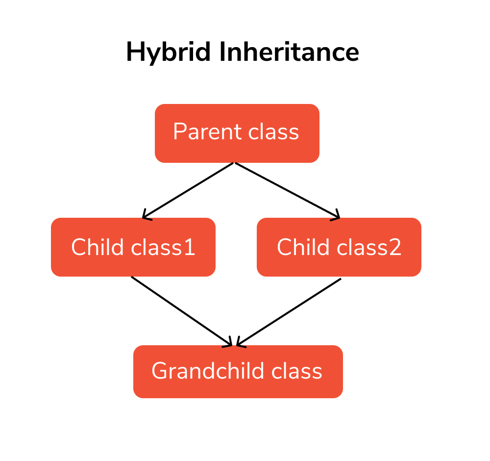

```python
class School:
     def func1(self):
         print("This function is in school.")

class Student1(School):
     def func2(self):
         print("This function is in student 1. ")

class Student2(School):
     def func3(self):
         print("This function is in student 2.")

class Student3(Student1, School):
     def func4(self):
         print("This function is in student 3.")

# Driver's code
object = Student3()
object.func1()
object.func2()
```

```
This function is in school.
This function is in student 1.
```

```python
class A:
  def m(self):
    print("method from Class A....")

class B(A):
    pass
class C(A):
  def m(self):
    print("method from Class C....")

class D(B, C):
    pass

kk = D()
kk.m()
```

```
method from Class C....
```

#### Diamond/cyclic Inheritance

The concept of inheritance properties from one class to another class in cyclic way, is called Cyclic inheritance. Python won't support for Cyclic inheritance.

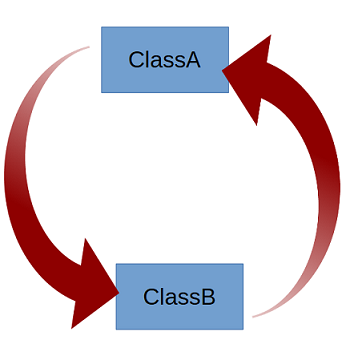

```python
class A(B):
    print('Hi')
class B(A):
    print('Hello')
ii = B()
```

[output not shown]